# ACCESS-OM2 & Bash Tips and Tricks

Maurice F. Huguenin, m.huguenin-virchaux@unsw.edu.au

Last compiled on 08 February 2024, 10:14:21 AEDT

[figure not shown]

Amundsen-Scott South Pole Station, Antarctica, Photo by Dana Hrubes

“Difficulties are just things to overcome, after all.” - Ernest Shackleton

# 1 Branching off an IAF perturbation simulation from the ACCESS-OM2-1 model

1. `mkdir 1deg_jra55_iaf_Atlantic` and `cd` into it
2. git clone the branch from where I would like to complete simulation: `git clone -b Pacific git@github.com:mauricehuguenin/1deg_jra55_iaf.git ./`
3. Passphrase is the ETH password with ending `*15`, only one `5`
4. `git branch` to check on which branch I am currently at
5. change input files in `config.yaml` accordingly
6. create a new branch using `git checkout -b Atlantic` and push that branch with `git push -u origin Atlantic` 6.1 if not the first time pushing, first use `git add .` and `git commit`
7. check on github if I have a new branch and everything is done correctly
8. make an archive directory on scratch: `mkdir /scratch/e14/mv7494/access-om2/archive/1deg_jra55_iaf_Atlantic`
9. update the archive link with `ln -sfn /scratch/e14/mv7494/access-om2/archive/1deg_jra55_iaf_Atlantic archive`
10. make sure the archive link is the same as the project name in `config.yaml`
11. change `jobname` in `config.yaml`
12. if running on `v45` instead of `e14`, make sure to add the following option in `config.yaml`: `shortpath: /scratch/e14` to force payu to always find, and save, files in this short (or scratch) project directory
13. change `accessom2.nml` to

```
    forcing_start_date = '1972-01-01T00:00:00'
    forcing_end_date = '2018-01-01T00:00:00'
```

14. copy over `output200` and `restart200` to the archive folder
15. make sure I have `cice_in.nml` in `output200/ice`
16. check/fix `FORCING_CUR_DATE` and `EXP_CUR_DATE` in `archive/restart200/accessom2.restart.nml` to

```
 &DO_NOT_EDIT_NML
 FORCING_CUR_DATE        = 1972-01-01T00:00:00,
 EXP_CUR_DATE    = 1972-01-01T00:00:00
 /
```

```
     3        (Calendar: no_calendar=0, thirty_day_months=1, julian=2, gregorian=3, noleap=4)
  1972     1     1     0     0     0        Model start time:   year, month, day, hour, minute, second
  1972     1     1     0     0     0        Current model time: year, month, day, hour, minute, second
```

18. for the first submit, use `use_restart_time=.false.` in `ice/cice.nml`. If doing the CTRL run, use `use_restart_time=.false.` throughout all submits
19. make sure I have the correct executable for mom:

```
    - name: ocean
      model: mom
      exe: /g/data/e14/rmh561/access-om2/bin/fms_ACCESS-OM_fd3e1a3_libaccessom2_a9d4b67.x
      input: /g/data/ik11/inputs/access-om2/input_236a3011/mom_1deg
      ncpus: 216
```

20. make sure I have the correct input for the mom model:

```
input:
            - /g/data/ik11/inputs/access-om2/input_236a3011/yatm_1deg
            - /g/data/e14/mv7494/HeatDist_input/EXP_Atlantic_JRA55-do-1-3/rsds
            - /g/data/e14/mv7494/HeatDist_input/EXP_Atlantic_JRA55-do-1-3/rlds
            - ...
```

21. make sure I have the correct `ocean/diag_table` and correct frequencies for the output

```
# output files
"ocean_month",      1,  "months", 1, "days", "time",
"ocean",            12,  "months", 1, "days", "time",
"ocean_grid",      -1,  "months", 1, "days", "time",
"ocean_scalar",     1,  "months", 1, "days", "time",
"ocean_snap",      12,  "months", 1, "days", "time",
"ocean_wmass",     12,  "months", 1, "days", "time",
"ocean_heat",      12,  "months", 1, "days", "time",
```

22. `payu setup` and `payu sweep` to establish the new manifest paths
23. to check in real-time if the model uses the correct input:

```
tail -f work/atmosphere/log/matmxx.pe00000.log
```

I saved this now as the alias `tailcheck` in the `~/.bashrc` file. This command must be run in the folder from where I use the payu commands.

24. after first submit, use `use_restart_time=.true.` in `ice/cice.nml`

→ link to Andrew’s wiki: https://github.com/COSIMA/access-om2/wiki/Tutorials#starting-a-new-experiment-using-restarts-from-a-previous-experiment

# 2 Turning on WMT diagnostics in the CTRL simulation

1. replace MOM executable with the following: `exe: /g/data/e14/rmh561/access-om2/bin/fms_ACCESS-OM_da70c54_libaccessom2_4198e15.x`
2. use the `diag_table` from `/home/561/rmh561/access-om2/1deg_jra55_iaf/ocean/diag_table_Maurice` which I renamed `diag_table_WMT`
3. update the `&ocean_density_nml` namelist in `ocean/input.nml` to:

```
&ocean_density_nml
    neutral_density_theta = .true.
    neutral_density_potrho = .false.
    nrho_face_bin = .true.
    eos_linear = .false.
    eos_preteos10 = .true.
    layer_nk = 74
    neutralrho_min = -3.0
    neutralrho_max = 34.0
    potrho_max = 1038.0
    potrho_min = 1028.0
/
```

4. for the first commit, use `use_restart_time=.false.` in `ice/cice.nml`

# 3 How to branch off a perturbation simulation and configuring everything through .git

1. mkdir `1deg_jra55_iaf_Pacific`
2. set github connection with `git remote set-url origin git@github.com/mauricehuguenin/1deg_jra55_iaf`
3. have a look at what branches I have`git branch`
4. create a new branch called Pacific with `git checkout -b Pacific`
5. `git branch` and `git status` to check files
6. push to github with `git push origin -u Pacific`
7. enter password if necessary (the SSH connection set up on 2020-09-22 requires the ETH password with *15, i.e. a single 5 at the end)
8. `git branch`
9. `git clone git@github.com:mauricehuguenin/1deg_jra55_iaf.git ./` to download the config files from the github repo
10. `git checkout --track origin/Pacific` to track changes in the new `Pacific` branch
11. `git checkout -b Pacific`
12. after the changes are done and a new run is up I can then do `git push origin -u Pacific` again to push the changes up to github

# 4 Setting the ACCESS-OM2 time step

The timestep is normally set to a factor of the JRA55-do forcing period of 3hr = 10800s, for example one of 100, 108, 120, 135, 144, 150, 180, 200, 216, 225, 240, 270, 300, 360, 400, 432, 450, 540, 600, 675, 720, 900, 1080, 1200, 1350, 1800, 2160, 2700, 3600 or 5400s. The default timestep for this configuration is 1350 seconds, and the model is stable with this timestep right from the start. After the first year or two of model equilibration you may be able to run with a 1800s timestep for faster throughput.

# 5 Check CPU usage of job running on Gadi

`nqstat_anu job_id`

# 6 Calculate trend files of control simulation with CDO

`cdo trend -mergetime output20*/ocean/ocean.nc trend_mergetime_ocean.nc &`

# 7 Calculating the linear trend in the ocean_wmass.nc file

- This file is too big to use `cdo detrend ifile ofile` as it cannot load all the timeseries into memory

```
# (I) merge files, select correct time period and variables
cdo.selvar(var, input = '-selyear,1972/2017 -mergetime ' + base+'output20*/ocean/ocean_wmass.nc',
          output = base2+'mergetime_output201-205_ocean_wmass.nc', force=False)
# (II) calculate trend files
cdo.trend(input = base2+'mergetime_output201-205_ocean_wmass.nc',
          output = base2+'afile.nc ' + base2+'bfile.nc', force=False)
# (IV) remove the trend from the merged files, subtract the detrended data and multiply by (-1) to
# get: trend = climatology - (climatology - trend) * (-1)
cdo.mulc('-1',input = '-sub -subtrend ' + base2+'mergetime_output201-205_ocean_wmass.nc ' +
         base2+'afile.nc ' + base2+'bfile.nc ' + base2+'mergetime_output201-205_ocean_wmass.nc',
         output = base2+'trend_mergetime_output201-205_ocean_wmass.nc', force=False)
```

# 8 Check remaining allocation on Gadi

`nci_account -P e14 -v`

# 9 Copy data to or from Gadi

```
rsync -aruv <username>@gadi.nci.org.au:/path/on/gadi/filename.nc .
rsync -aruv <username>@gadi.nci.org.au:/path/on/gadi/filename.nc path/on/local/machine/filename.nc
```

# 10 Download Argo OBS from the internet directly to the terminal

Roemmich and Gilson, 2009 data from Scripps: http://sio-argo.ucsd.edu/RG_Climatology.html

```
wget ftp://kakapo.ucsd.edu/pub/gilson/argo_climatology/RG_ArgoClim_Temperature_2019.nc.gz
zcat RG_ArgoClim_Temperature_2019.nc.gz > RG_ArgoClim_Temperature_2019.nc # to unzip the .nc.gz file

# or
wget ftp://data.argo.org.cn/pub/ARGO/BOA_Argo/NetCDF/BOA_Argo_20{14..19}_{01..12}.nc

# or alternatively if it is a .zip file:
unzip \*.zip
```

Roemmich et al. (2015) data from https://www.seanoe.org/data/00311/42182/#42254:

```
wget https://www.seanoe.org/data/00311/42182/data/42254.tar.gz
tar -zxvf 42254.tar.gz # to unpack
```

# 11 Collating output after the simulation ends

- increase walltime of collate to `3:00:00` when WMT diagnostics are active as `ocean_wmass.nc` is quite a big file
- `module unload conda` followed by `module load conda` loads the default analysis3-20.01(analysis3:default) environment
- `payu collate -d archive/output051/ocean` then collates the `ocean_wmass.nc`` files
- it takes `Walltime Used: 01:06:11` for the 1deg_jra55_iaf configuration with WMT on # List all files in subfolders `find . -type f -printf "%f\n"`

# 12 Show CPU usage and memory percent

`/g/data/hh5/public/apps/nci_scripts/uqstat`

# 13 Rename variable and delete dimension in .nc file with CDO

change name from XT_OCEAN to xt_ocean and YT_OCEAN to yt_ocean respectively

`cdo chname,XT_OCEAN,xt_ocean,YT_OCEAN,yt_ocean ifilen.nc ofile.nc`

remove the dimension ‘ST_OCEAN1_1’

`ncwa -a ST_OCEAN1_1 ifile.nc ofile.nc`

# 14 Setting the Nino3.4 region to a certain value or selecting it

```
tos_nino34 = tos.isel(time=0).where((tos.lat>5) | (tos.lat<-5) | (tos.lon<190) | (tos.lon>240),273).plot()
tos_nino34 = tos.isel(time=0).where((tos.lat>5) | (tos.lat<-5) | (tos.lon>190) | (tos.lon>240), tos.isel)

# see also the __jra55_preparation_TROPICS_1972-2018_inverse_as_ryans_suggestion.ipynb__ script where I do it in an actual dataset
```

# 15 Start jupyter notebook from Bash on Ubuntu on Windows

`cd /mnt/c/Users/Maurice\ Huguenin/nci_scripts-master/`

`./gadi_jupyter`

`python3 vdi_jupyter.py`

Use the following command as pointed out by @scott on the ARCCSS support slack channel on the 25th of November 2020:

`./gadi_jupyter -s scratch/w35+gdata/v45`

To change settings in the gadi_jupyter notebook use

```
- vi gadi_jupyter
- ESC -> a
- make edits
- ESC -> : -> wq -> ENTER (write-quit)
```

- Password for `vdi_jupyter` is ending with `...555`

# 16 Make folder group-readable

`chmod -R g+rX ~/access-om2/1deg_jra55v131_iaf/`

[output not shown]

# 17 Display human-readable file sizes in the console

`ls -lh`

# 18 Replace values in xarray dataset by another value

```
basin_mask = xr.open_mfdataset('/g/data/e14/mv7494/basin_mask_mom_1deg.nc').BASIN_MASK
basin_mask = basin_mask.where(basin_mask != 4,2) # replace Arctic Ocean index values (i.e. 4) with
basin_mask.plot(cmap='tab20')                    # Atlantic Ocean index values (i.e. 2)
```

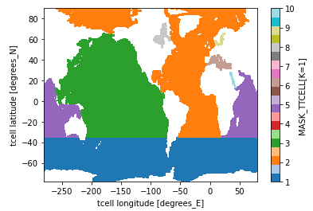

# 19 Revert ERA5 land-sea mask

Rewrite land-sea mask so that all ocean = 1 and all land = 0 instead of the other way around

```
lsm = xr.open_mfdataset('/g/data/e14/mv7494/ERA5_land_sea_mask_025deg.nc').lsm[0,:,:]
lsm = lsm.where(lsm == 0,2) # set all non-zero values (i.e.land) to index 2
lsm = lsm.where(lsm == 2,1) # set all non-land values (i.e. ocean) to index 1
lsm = lsm.where(lsm != 2,0) # set all land to index 0
lsm = lsm.where(lsm !=0) # replace all zeroes by nan
```

# 20 Create an area_t file for a specific grid cell resolution

In this example the JRA55-do-1-3 grid is (**latitude**: 320, **longitude**: 640)

```
res = [320,640] # resolution of grid (lat: 320, lon: 640)
dxt_JRA = np.full(res[0], (6371e3*2*np.pi)/res[0])     # half the circumference of the Earth divided by number of lat grids
dyt_JRA = np.full(res[1], (6371e3*np.pi)/res[1])   # circumference of the Earth divided by the number of lon grid cells

a = np.linspace(-np.pi/2, np.pi/2,res[0])
for l in range(res[0]):
    dxt_JRA[l] = np.cos(a[l]) * dxt_JRA[l] # scale with cosine of latitude


aa, bb = np.meshgrid(dyt_JRA,dxt_JRA) # create meshgrid
os.system('rm -r /g/data/e14/mv7494/ERA5/ERA5_grid.nc')
(landsea_mask*aa*bb).to_dataset(name='area_t').to_netcdf('/g/data/e14/mv7494/JRA55-do-1-3/JRA55-do-1-3_grid.nc') # ERA5 area
area_t_JRA = (landsea_mask*aa*bb)
```

[figure not shown]

- . - . - . - THIS ONE NOT CORRECT YET, DYT AND DXT VERTAUSCHT

# 21 Download File from Gadi to local machine/local desktop

```
rsync -aruv mv7494@gadi.nci.org.au:/home/561/mv7494/HeatDist_figures/ACCESS-OM2-1_control_overturning_streamfunction.png /mnt/c/Users/Maurice\ Huguenin/Desktop/
```

# 22 Redi diffusion

- Redi diffusion parameterizes eddy transport of heat along isopycnals and is significant only in the Southern Ocean.
- $\kappa$ = diapycnal mixing coefficient, ~0.3e-4 m$^2$ s$^{-1}$ in the upper 2000 m

# 23 What to do when I get: atm and ice models are out of sync

```
Error in accessom2_deinit: atm and ice models are out of sync.
atm end date: 2022-01-01T00:00:00.000
ice end date: 1966-01-01T00:00:00.000
```

# 24 How to create a public SSH key and add it to github

- `ssh-keygen -t rsa -b 4096 -C m.huguenin-virchaux@unsw.edu.au`
- ENTER = save in default directory
- enter passphrase, here for connection to gadi I use standard ETH password with *15, i.e. a single 5 at the end
- download file in `/home/561/mv7494/.ssh/id_rsa.pub` to local Windows 10 machine and open file with notepad
- copy the content to clipboard
- on github: go to Settings -> SSH and GPG keys
- add new SSH key with title `SSH Key GADI` Github is now configured for gadi where I created the key

# 25 How to plot boundary lines between the ocean basins using cartopy

```
# lon, lon, lat, lat
plt.plot([146, 146], [-34,  -90],color='b', transform=ccrs.PlateCarree()) # Tasmania - Antarctica
plt.plot([-71, -71], [-34,  -90],color='b', transform=ccrs.PlateCarree()) # Feuerland - Antarctica
plt.plot([180,200], [66,  66],color='b', transform=ccrs.PlateCarree()) # Beringstrasse
plt.plot([142,142], [-4,  -20],color='b', transform=ccrs.PlateCarree()) # Arnhemland - Papua Neu Guinea
plt.plot([115,142], [-8,  -8],color='b', transform=ccrs.PlateCarree()) # Guinea - Java
plt.plot([102,102], [0,  5],color='b', transform=ccrs.PlateCarree()) # Strasse von Malakka
```

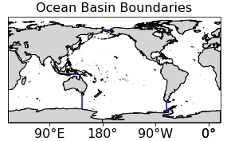

# 26 How to adapt the ./gadi_jupyter.py script in vim

- edit: `ESC -> a -> insert change`
- write, save and close script: `ESC -> :wq`

# 27 How to open Julia programming language

`START` -> `Anaconda Navigator (Anaconda3)` -> open `jupyterlab` (should open new tab in firefox) -> click `Julia 1.5.2`

# 28 How to delete branch locally and remotely with git

```
// delete branch locally
git branch -d localBranchName

// delete branch remotely
git push origin --delete remoteBranchName
```

# 29 How to locate ERA5 data on Gadi

For example here the 2 meter surface air temperature values:

```
t2m = xr.open_dataset('/g/data/ub4/era5/netcdf/land/t2m/2019/t2m_era5land_global_20191201_20191231.nc').t2m
t2m = t2m.sel(time='2019-12-19').mean('time') - 273.15
t2m.plot()
plt.savefig(save + 'era5_t2m_20191219', dpi=300, facecolor='w',
            edgecolor='w', orientation='landscape', papertype=None,
            format=None, transparent=False, bbox_inches='tight',
            pad_inches=0.1, metadata=None)
# Wall time: 7.48 s
```

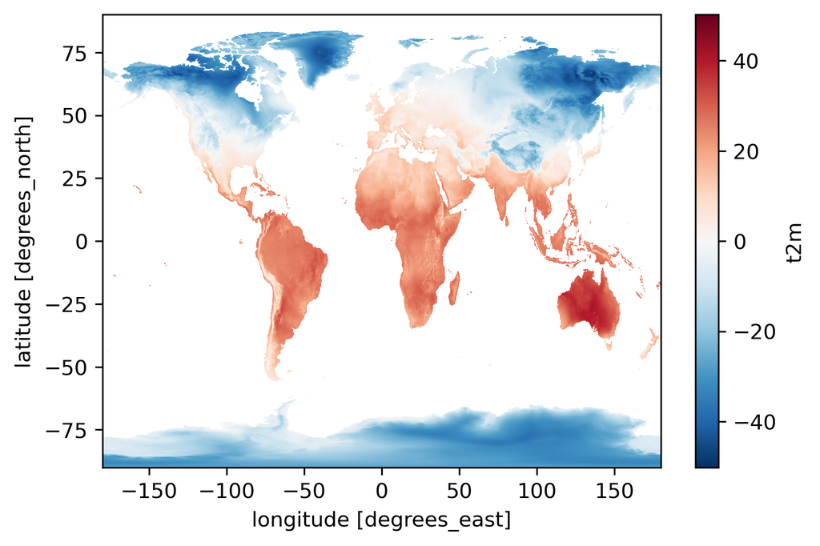

# 30 How to create the linear trend in a netcdf file (for example in JRA55-do’s SAT files)

```
cdo -detrend -selyear,1972/2018 -yearmean -mergetime ifile.nc ofile.nc
cdo yseassub ifile.nc -yseasavg ifile.nc ofile.nc
cdo trend ifile.nc intercept.nc trend.nc
```

# 31 Citations in the AGU LaTeX template

`\cite{kiss2019access}` -> (Kiss et al., 2019)

`\citeA{kiss2019access}` -> Kiss et al. (2019)

`\cite<KPP,>{large1994oceanic}` -> (KPP, Large et al., 1994)

# 32 Rotblau Colorbar in Python

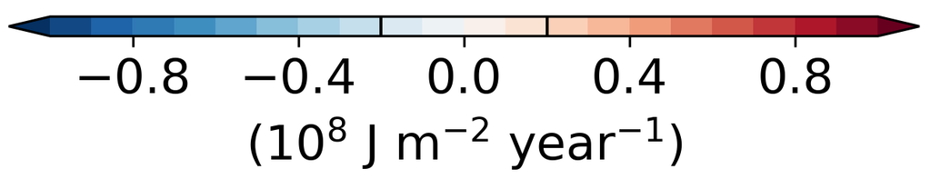

```
rotblau = [[0.4 , 0.  , 0.12], [0.47, 0.02, 0.13], [0.62, 0.07, 0.16], [0.66, 0.16, 0.2],
           [0.8 , 0.3 , 0.27], [0.87, 0.44, 0.35], [0.93, 0.58, 0.45], [0.96, 0.7 , 0.58],
           [0.98, 0.8 , 0.71], [0.98, 0.94, 0.92], [0.93, 0.95, 0.96], [0.85, 0.91, 0.95],
           [0.76, 0.87, 0.93], [0.64, 0.8 , 0.89], [0.49, 0.72, 0.84], [0.34, 0.62, 0.79],
           [0.23, 0.53, 0.74], [0.16, 0.44, 0.7] , [0.1 ,0.35, 0.6], [0.05, 0.24, 0.45],
           [0.02, 0.19, 0.38]]
```

# 33 Scientific Notation in R

`print(3.5e23/6.3e13, dig=3)` gives the result with exponent The values here represent the total ocean heat uptake 1971-2018 (J) divided by the energy of one Hiroshima atom bomb (J).

# 34 Calculating moving average in python

```
import bottleneck as bn

OHC_access = bn.move_mean(OHC_access, window=5, min_count=1)
plt.plot(OHC_access)
```

# 35 Downloading NOAA ERSSTv5 (Huang et al., 2017)

```
wget https://www.ncei.noaa.gov/pub/data/cmb/ersst/v5/netcdf/ersst.v5.19{58..72}{01..12}.nc
```

# 36 Calculating anomalies using the Climate Data Operator (CDO) commands

```
# merge files, select temperature, calculate annual mean, select 1958-2017 and detrend the data
cdo -detrend -selyear,1958/2017 -yearmean -selvar,temp -mergetime ifile*.nc ofile.nc

# calculate seasonal average & subtract it from the original data
cdo -yseassub ifile.nc -yseasavg ifile.nc ofile.nc

# calculate the linear trend over the 1962-1971 period
cdo -trend -selyear,1962/1971 ifile.nc intercept.nc trend.nc
```

# 37 Creating a land-sea mask from ocean data

```
tos = xr.open_mfdataset(base_jra + fname + '*.nc').tos[0,:,:].load() # load in temperature at ocean surface
tos = tos.fillna(0) # replace all nan with zeroes
landsea_mask = tos.where(tos>=0,1).where(tos<=0,1).where(tos != 0) # replace all non-zero data with ones and all ones with NaN
```

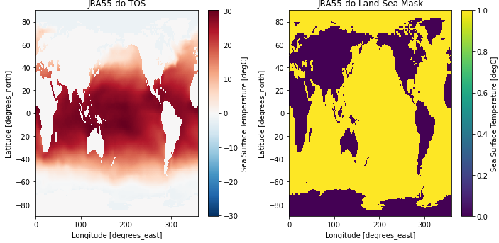

- I already created a *land_sea_mask_320x640.nc* in /g/data/e14/mv7494/JRA55-do-1-3

# 38 How to change the jupyter notebook start up folder in Anaconda

1. open Anaconda navigator
2. on the left click environments and select `pyn_env`, open terminal
3. in terminal: `jupyter notebook –generate-config` and Enter. This will create a file with the name `jupyter_notebook_config.py` in the location `C:\Users\Maurice Huguenin\.jupyter`
4. open `jupyter_notebook_config.py` and search for `#c.NotebookApp.notebook_dir = ''`
5. uncomment that line and add custom file path to the section on the right, e.g.,

```
c.NotebookApp.notebook_dir = 'Y:/Maurice Huguenin/in2021_v3/Scripts/'
```

6. save, exit and restart Anaconda Navigator for changes to come into effect

Source:

```
https://www.planetofbits.com/python/change-jupyter-notebook-startup-folder-anaconda/
```

# 39 Seeing which users of e14 use the most data on /g/data

```
nci-files-report -p e14 -f gdata
```

# 40 Check how much storage is in my gadi home folder

- to see if I exceed disk quota
- as per Slack message from the 30th of September 2022 from Paola: **home only has 10GB**

```
du -hs $HOME/*
```

# 41 Using wget to download SODA reanalysis files

- `-nc` flag to skip files that have already been downloaded

```
wget -r -l1 --no-parent --progress=bar -nd -nc -A.nc https://dsrs.atmos.umd.edu/DATA/soda3.12.2/REGRIDED/ocean/
```

# 42 Take annual mean of an xarray data set

- `xr.open_mfdataset(base + 'tas/tas*.nc').groupby('time.year').mean('time')`

# 43 Repeat time series n times in python

- goal: repeat `[0, 1, 2]` three times
- `np.array(list(np.arange(0,3))*3)` or
- `np.array([0, 1, 2]*3)`

# 44 Check why scripts are not running on gadi

- using `uqstat`

`/g/data/hh5/public/apps/nci_scripts/uqstat -P e14 --comment`

# 45 How to download and unzip .tar file with wget using only one command

```
wget -c http://path/to/file/file.tar.gz -O - | tar -xz
```

# 46 Replace fill value in dataset with nan

- fill value here is -1e3

```
had = xr.open_dataset('/g/data/e14/mv7494/HadISST/' + 'HadISST_sst.nc')
had = had.where(had!=-1000).fillna(np.nan).sst
```

# 47 ERA-5 u10, v10 and SST location

```
/g/data/rt52/era5/single-levels/reanalysis/
```

- u10
- v10
- sst

# 48 Comparing my local branch with a remote branch on github using git diff

- Check on which branch I am currently at `git branch`
- Push that branch up to github: `git push -u origin ENSOWind`
- Add remote repo from Ryan: `git remote add ryan git@github.com:rmholmes/025deg_jra55_ryf.git`
- Fetch Ryan’s repo back down: `git fetch ryan`
- Git diff all the changes in my repo compared to Ryan’s: `git diff ENSOWind ryan/ryf9091_gadi`
- To compare only a single file, use `git diff ryan/ryf9091_gadi:config.yaml config.yaml`

# 49 Check how much space my folders are using in $HOME

```
module purge
module use /g/data3/hh5/public/modules
module load conda/analysis3
```

- `ncdu /home/561/mv7494` then gives the analysis how large each folder is

# 50 Loading in a subset of output data from a model simulation

Given the data is all stored in the same folder and that the outputs are labelled output000, output001, output002, …

```
%%time
base    = ['/g/data/e14/mv7494/access-om2/archive/', '/scratch/e14/mv7494/access-om2/archive/', '/scratch/e14/mv7494/access-om2/archive/']
exp     = ['01deg_jra55_ryf_Control', '01deg_jra55_ryf_IPOPos','01deg_jra55_ryf_IPONeg']
file    = ['ocean_month.nc', 'ocean_month.nc', 'ocean_month.nc']
# ---------------------------------------------------------------------------------- #
sel_lat = [   0,  500]  # 81.1°S - 59.5°S                                            #
sel_lon = [ 800, 2600]  # [1299, 2200] = 150°W - 60°W                                #
depth   = [  23,   47]  # 100 m to 1000 m
# ---------------------------------------------------------------------------------- #
var = ['temp']
for e in [1,2]: # loop through the two simulations ENFull and LNFull
    print(exp[e])
    if e == 1: last_output = 981; nr_outputs = 4 # for ENFull, I only have output976-output980
    if e == 2: last_output = 981; nr_outputs = 4

    a = [i for i in range(last_output+1-nr_outputs,last_output+1)] # create integer list
    s = list(range(0,nr_outputs))
    c = []; d = []; t = []; u = []; q = [] # empty list which I fill up; c for control, d for perturbation simulation
    for i in s: # loop through the number of files I would like
        # fill in empty list with integers trailing two zeros (000, 001, 002, ...)
        c.append(i); c[i] = base[0] + exp[0]+'/output'+str(a[i]).zfill(3) + '/ocean/' + file[0] # string with all file locations
        d.append(i); d[i] = base[e] + exp[e]+'/output'+str(a[i]).zfill(3) + '/ocean/' + file[e]

    data_clim   = xr.open_mfdataset(c,combine='by_coords',chunks = {'yt_ocean': '200MB', 'xt_ocean': '200MB'},
                                    decode_times = True)[var[0]][:, depth[0]:depth[1], sel_lat[0]:sel_lat[1], sel_lon[0]:sel_lon[1]] # open data sets
    data        = xr.open_mfdataset(d,combine='by_coords',chunks = {'yt_ocean': '200MB', 'xt_ocean': '200MB'},
                                    decode_times = True)[var[0]][:, depth[0]:depth[1], sel_lat[0]:sel_lat[1], sel_lon[0]:sel_lon[1]]
    if e == 1: data_IPOPos_anom       = ((data - data_clim)*above1000_tcells).load() # with masking
    if e == 2: data_IPONeg_anom       = ((data - data_clim)*above1000_tcells).load() # with masking
print('----------------------------------')
data_IPOPos_anom[0,:,:,:].mean(['st_ocean']).plot() # Wall time: 6.93 s
```

# 51 Fetching a specific commit from the COSIMA github

- clone the repository or fetch all the latest changes and commits
- `git log` to check out which specific hash key I need

```
commit 2eb6a35c0b20cf9f7751918cdfa9c221e92ad451
Merge: b30dae4 4662775
Author: Nic Hannah <nichannah@pm.me>
Date:   Thu Apr 16 22:16:17 2020 +1000

    Merge pull request #5 from COSIMA/feat-155-JRA55-v1p4-compat

    Modify JRA55 v1.3 config to be compatible with JRA55 v1.4 exes
```

- copy the commit (SHA) id and checkout using `git checkout 2eb6a35c0b20cf9f7751918cdfa9c221e92ad451`
- alternatively use the short form of the SHA ID `git checkout 2eb6a35c`
- create new branch with the commit: `git checkout -b Apr20 2eb6a35c`

# 52 How to change the line number colour in Word

- Enable line numbers via `Layout` -> `Line Numbers`
- Go to the Home tab of the Ribbon after enabling line numbering.
- Under Styles, click the Dialog Box Launcher arrow to open the Styles pane.
- In the Styles pane, click Options.
- Under `Select styles to show` in the Options window, select `All styles`. Under “Select how list is sorted”, select `Alphabetical`; this option makes it easier to locate the style in question.
- Click OK to exit out of the Options window.
- Back in the Styles pane, scroll down until you find the Style that is called `Line Number`. Click the arrow next to it, hit Modify, and change formatting as necessary in the window that opens (including changing the colour and font). Click OK once you’re finished and then close the Styles pane.

# 53 Starting a gadi_jupyter session

```
cd /mnt/c/Users/Maurice\ Huguenin/nci_scripts-master2/
./gadi_jupyter2
```

# 54 Solving the `Cannot combine along dimension` error

- TypeError: Cannot combine along dimension ‘time’ with mixed types. Found: Timestamp, DatetimeGregorian.
- Scott Wales: Default python datetimes only work for the present +/- a couple hundred years. outside that xarray uses cftime, which is a more flexible library but not as well supported as the default datetimes.
- use the extra flag `use_cftime=True` when loading the data with `xr.open_mfdataset()`

# 55 Display current jobs running in the group

`nqstat`

# 56 Select specific colour from a matplotlib colormap

```
cmap = plt.cm.get_cmap('YlOrRd') # create Yellow -> Orange - Red colour map
plt.plot(rlds_zonal, rlds.lat, color=cmap(0.9)) # dark red time series
```

[figure not shown]

# 57 Interpolate a time series using np.interp

```
# interpolated time series = np.interp(target length, original length, original data)
lw_heat_zonal_interp = np.interp(np.linspace(0,320,320), np.linspace(0,300,300), lw_heat_zonal)

plt.figure(figsize=(12,4)); plt.plot(lw_heat_zonal, label='original')
plt.plot(lw_heat_zonal_interp, '*', label='interpolated'); plt.legend()
print('from '+str(len(lw_heat_zonal))+' to '+str(len(lw_heat_zonal_interp))+' data points')
```

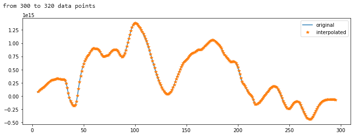

# 58 Doing an EOF analysis in python -> As in Huguenin et al. (2020b)

1. Regress N34 onto wind stress anomalies
2. Remove anomalies associated with N34 from the data set
3. Calculate first EOF of the residuals over 100°E-60°W, 10°S-10°N = PC2 time series
4. Regress N34 and PC2 time series onto all atmospheric fields to get two spatial patterns each
5. Total anomalous perturbation forcing = N34 x Pattern1 + PC2 x Pattern2

```
# Steps (i) and (ii)
f11 = out+'monthly_mean/JRA55-do-'+forcing+'_'; f22 = '_monthly_mean_'+period[0]+'-'+period[1]+'.nc'
# remove monthly mean to calculate anomalies
ts = xr.open_dataset(f11 + 'ts' + f22).ts.groupby('time.month') - (xr.open_dataset(f11 + 'ts' + f22).ts.groupby('time.month').mean('time'))
N34_JRA = ts.isel(lat=slice(150,170)).isel(lon = slice(338,428)).mean(['lat','lon']) # N34 region: 5°S-5°N and 170°W-120°W -> -5.335°S ... 5.335°S, 190.1°E ... 240.2°E

taux = xr.open_dataset(f11 + 'taux' + f22).taux.groupby('time.month') - (xr.open_dataset(f11 + 'taux' + f22).taux.groupby('time.month').mean('time'))
res = taux - (taux*N34_JRA)
# Wall time: 43.9 s
```

```
# Step (iii)
from eofs.xarray import Eof
solver = Eof(res.drop('month').isel(lat = slice(141,179)).isel(lon = slice(178,535))) # EOF region: 10°S-10°N and 100°E-60°W, drop the 'month' attribute so it works
pcs = solver.pcs(npcs=2, pcscaling=1)
eofs = solver.eofs(neofs=2, eofscaling=1)
```

```
# Step (iv)
plt.figure(figsize=(16,9))
plt.subplot(2,1,1); plt.axhline(0, c='grey', linewidth=.5); plt.title('N34 and PC2 time series'); plt.plot(N34_JRA); plt.plot(pcs[:,1])
plt.subplot(2,2,3); (N34_JRA*taux).mean(['time']).plot(); plt.subplot(2,2,4); (pcs[:,1]*taux).mean(['time']).plot()
```

# 59 Surface heat flux components in ACCESS-OM2

total heat flux = `net_sfc_heating + frazil_3d_int_z`

where,

`net_sfc_heating = sfc_hflux_coupler + sfc_hflux_pme + sfc_hflux_from_runoff + sfc_hflux_from_calving`

`sfc_hflux_coupler = swflx + lw_heat + fprec_melt_heat + calving_melt_heat + sens_heat + evap_heat + mh_flux + liceht` Note the calving terms and liceht are currently zero in ACCESS-OM.

- `frazil_3d_int_z` = heat flux from frazil ice
- `sfc_hflux_pme` = surface heat flux from precipitation minus evaporation
- `sfc_hflux_from_runoff` = surface heat flux from river runoff
- `sfc_hflux_from_calving` = surface heat flux from calving ice sheets
- `swflx` = net shortwave heat flux
- `lw_heat` = net longwave heat flux
- `fprec_melt_heat` = heat flux out of the ocean required to melt frozen precipitation when it falls in the ocean
- `calving_melt_heat` = heat flux from calving (again?)
- `sens_heat` = sensible heat flux
- `evap_heat` = evaporative/latent heat flux
- `mh_flux` = heat flux out of the ocean associated with melting sea ice
- `liceht` = is another ice exchange term, but I’m pretty sure it is 0 in ACCESS-OM2

# 60 Getting the 1000 dbar isobath from ACCESS-OM2

- also sometimes called topography or bathymetry

```
topo = xr.open_dataset('/g/data/ik11/inputs/access-om2/input_20200530/mom_025deg/topog.nc').depth
field = xr.open_mfdataset(base+run[0]+'/output325/ocean/ocean.nc').temp[11,0,:,:]
field.values = topo.values # write topography data into [yt_ocean, xt_ocean] array structure
```

# 61 How to make a quick plot with multiple panels in xarray

```
anom.mean(['st_ocean'])[EN_periods[4]:EN_periods[5],:,:].plot.imshow("xt_ocean", "yt_ocean", col="time", col_wrap=12, robust=True)
```

gives

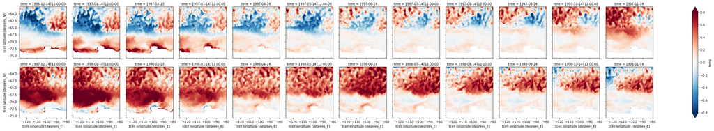

# 62 Print out the time dimension with `ncdump`

`ncdump -t -v time ts_mean_anoms_EN.nc`

# 63 How to shift a datetime object forward or backward

```
from datetime import timedelta
```

`datetime` arithmetic works kind of like normal arithmetic: you can add a `timedelta` object to a datetime object to shift its time:

```
dt = # some datetime object
dt_plus_12 = dt + timedelta(hours=12)
```

Also you can subtract two `datetime` objects to get a `timedelta` representing the difference between them:

```
dt2 = # some other datetime object
ONE_MINUTE = timedelta(minutes=1)
if abs(dt2 - dt) > ONE_MINUTE:
    # do something
```

# 64 Adding a cyclical point of longitude to avoid the white space in cartopy

```
from cartopy.util import add_cyclic_point
```

```
# add one longitude to avoid white space at 80°E
data, lon = add_cyclic_point(Qnet_1deg_map.values, Qnet_1deg_map.xt_ocean)
Qnet_1deg_map = xr.DataArray(data, coords={'yt_ocean':Qnet_1deg_map.yt_ocean, 'xt_ocean':lon}, dims=('yt_ocean','xt_ocean'))

# p1 = (Qnet_1deg_map/1e8).plot.contourf(cmp='RdBu_r',levels=ticks,add_colorbar=False,extend='both',transform=ccrs.PlateCarree())
# p11 = (Qnet_1deg_map/1e8).plot.contour(levels = [0], linewidths=.1, colors='lightgrey', transform=ccrs.PlateCarree(), alpha=.5)
```

# 65 Adding a legend in matplotlib outside of the figure and extending the plot so that the legend does not get cut off when using plt.savefig()

```
lgd = fig.legend(ncol=4,fontsize=16, bbox_to_anchor=(.5, -.09), loc='lower center')
plt.savefig(save + 'Zonal_forcing_and_SST_trends.pdf', bbox_extra_artists=(lgd,), bbox_inches='tight')
```

# 66 Create a movie out of different frames

- save each frame as a figure with continuing interger numbers, e.g.
  - AS_BS_cross_slope_sections_10.png
  - AS_BS_cross_slope_sections_11.png
  - AS_BS_cross_slope_sections_12.png, …
- create movie via

```
ffmpeg -framerate 30 -pattern_type glob -i 'AS_BS_cross_slope_sections_*.png' -vf scale=-2:1080,setsar=1 test.mp4
# same command to create a .avi file, use -q:v 1-5 to increase resolution between 1 and 5
ffmpeg -framerate 30 -pattern_type glob -i "10m_speed_frame_*.png" -vf scale=-2:1080,setsar=1 -q:v 3 test.avi
```

- a 3-month movie has a good length with `-framerate 12`

# 67 Add leading zeroes to filenames in a loop

`filename = 'image_month'+str('%03d' % (i,))+'.png'` gives `image_month001.png, _month002.png, _month003.png, etc.`

# 68 Remove ability for folder to be deleted

```
$ mkdir test_folder
$ > text.txt                                      # create file within folder
$ chmod u-w test_folder/                          # remove user permission to write
$ rm -rf test_folder/                             # try to delete folder
rm: cannot remove 'test_folder/text.txt': Permission denied
$ chmod u+w test_folder/                          # once again give user permission to write again
$ rm -rf test_folder/                             # folder can be deleted
```

# 69 Adding a rectangle bounded region to a projection in cartopy

```
import matplotlib.pyplot as plt
import cartopy.crs as ccrs

plt.figure(figsize=(16,6));
ax = plt.axes(projection=ccrs.Robinson(central_longitude=200))
ax.coastlines(resolution='110m'); ax.gridlines()
region = [-130, -40, -50, 20]
ax.gridlines(color='orange', linewidth=3, alpha=1 , xlocs=[region[0], region[1]], ylocs= [region[2], region[3]],
             xlim=[region[0], region[1]], ylim=[region[2], region[3]]) # orange rectangle
```

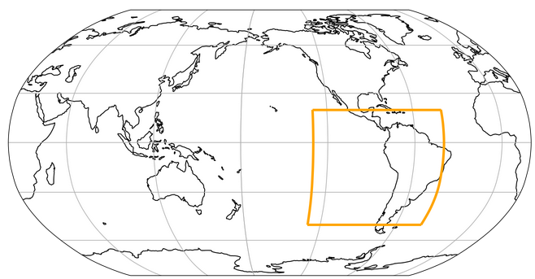

# 70 Fixing the gap between two time series to make it a continuous one

- See my Nature Communications paper, Fig. 1c

```
# combining the spin-up and scaling time series
ds = xr.combine_by_coords([ds5,ds8], compat='no_conflicts')
plt.plot(ds.year-1962,ds.total_ocean_heat,c = 'orange', linewidth=5)

# plotting the original two time series on top
p1 = plt.plot(ds5.year-1962,ds5,c = rotblau[3], linewidth=2)
p1 = plt.plot(ds8.year-1962,ds8,c = rotblau[3], linewidth=2)
```

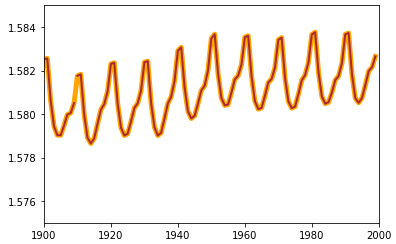

# 71 Plot border around figure to see how much empty space I have in my plot

`fig.patch.set_linewidth(10); fig.patch.set_edgecolor('cornflowerblue')`

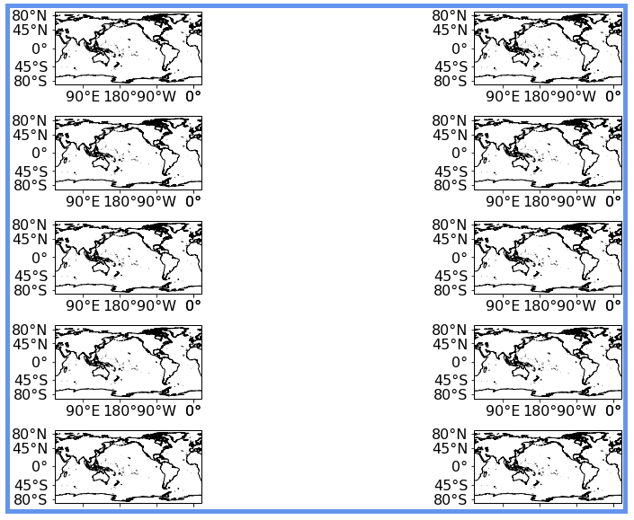

# 72 How to include the manuscript references in the same .tex file

- Copy all bibtex references in references.bib
- Convert bibtex to bib items using an online converter, e.g., https://asouqi.github.io/bibtex-converter/
- Include bib items one by one in the .tex file at the very end

```
\pagebreak
\section*{References}
\begin{thebibliography}{1}
\bibitem{schuckman2020heat}Schuckmann, K., Cheng, L., Palmer, M., Hansen, J., Tassone, C., Aich, V., Adusumilli, S., Beltrami, H., Boyer, T., Cuesta-Valero, F., Desbruy\`eres, D., Domingues, C., Garc\'ia-Garc\'ia, A., Gentine, P., Gilson, J., Gorfer, M., Haimberger, L., Ishii, M., Johnson, G., Killi…
\bibitem{...}
\bibitem{...}
\bibitem{...}
....
\end{thebibliography}

\end{document}
```

# 73 Get the full disk quota and storage limits of all gadi projects I am a part of

- `lquota` gives as output the disk storage we use/have left on e14 and v45:

```
           fs      Usage     Quota     Limit   iUsage   iQuota   iLimit

   e14 scratch  106.84TB   120.0TB   120.0TB  2312177  7954000  7954000
   v45 scratch   123.6TB   160.0TB   160.0TB  5110260 50000000 50000000
   ...     ...       ...       ...       ...      ...      ...      ...
   e14   gdata   64.09TB    67.0TB   70.35TB  4103159  4770000  5008500
   hh5   gdata  589.79TB   685.0TB  719.25TB  5604790 36476000 38299800
   v45   gdata  166.08TB   168.0TB   176.4TB  5640347 10633000 11164651
```

# 74 Loop through a list in python, selecting every pair

```
%%time
N34_EN_max = np.zeros(4)
EN_periods = [168, 192, 288, 312, 467, 491, 683, 707]

for f,g in zip(EN_periods[0::2],EN_periods[1::2]): # loop through the pairs
    print(f)
    print(g)
    print('---')
```

Gives as output:

```
168
192

288
312

467
491

683
707
```

- Alternatively, loop through a slice/block of ten integers:

```
for f,g in zip(a[0::10],a[10::10]): # loop through the pairs
    f = int(f); g = int(g)
```

# 75 How to interpolate a time series like a boss

- goal: interpolate N34 from 24 values (monthly res.) to 27 values or alternatively 2920 values (3-hourly)

```
%%time
from scipy.interpolate import interp1d # using scipy here

x_old = np.linspace(0,24,24) # original x-axis
f_linear = scipy.interpolate.interp1d(x_old,EN_mean) # interpolation function

x_new = np.linspace(0,24,27) # new x-axis -> can also use (0, 24, 2920)
EN_mean_interp = f_linear(np.linspace(0,24,27)) # interpolated time series

plt.plot(x_old, EN_mean, color = 'blue', label='N34_mean')
plt.scatter(x_new, EN_mean_interp, color = 'black', label='27 Punkte statt 24'); plt.legend()
# Wall time: 50.1 ms
```

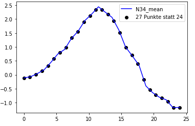

# 76 How to fix `remap transport: bad departure points` error in ACCESS-OM2-01

- Andrew Kiss: this is a CICE CFL error (ice moving more than 1 cell in 1 timestep) and can be resolved by reducing ice_ocean_timestep. Maybe try 360s? Might need to increase the walltime limit proportionally.

# 77 How to move items using rsync instead of copying them

```
rsync -aruv --remove-source-files --progress <input> <path/to/folder> &&  find <input> -type d -empty -delete
```

- The second part after `&&` deletes the empty folders but only when empty
- BE CAREFUL WITH THIS!!!

# 78 How to check at which time step of the forcing the model is now

For this to work, I need to be in the folder from where I run `payu run -n` `alias tailcheck='tail -f work/atmosphere/log/matmxx.pe00000.log'`

# 79 How to mask out some data and replace all data with a single index, e.g., 1

```
AS_profiles = (lon.where((lon > -120) & (lon < -101))).fillna(np.nan) # mask out all Amundsen Sea profiles, set the ones which do not fit in the box to nan
AS_profiles.where(np.logical_or(AS_profiles.isnull(), xr==0), 1) # replace all non-nan with 1
```

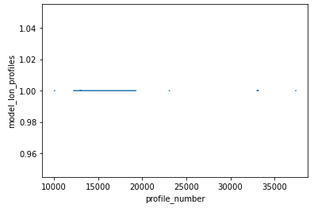

# 80 Find maximum value in an xarray data set

- `slp_anom.where(slp_anom == slp_anom.max(), drop=True)` gives

```
xarray.DataArray, 'psl' (lat: 1lon: 1)
array([[4.566505]], dtype=float32)
Coordinates:
        lon
        (lon)
        float64
        262.7
        lat
        (lat)
        float64
        -59.81
    Attributes: (0)
```

# 81 Import field from the fourth ACCESS-OM2-01 cycle using the cosima cookbook

```
%%time
# ---------------------------------------------------------------------------------- #
time      = [   2,   55]  # [  30, 1613] = 2012-12-01 to 2017-04-01 just like SOSE   #
depth     = [   0,   47]  # [  0,    47] = 0.5 m - 1017 m                            #
sel_lat   = [   0,  471]  # [120,   263] = 76.03°S - 70.04°S                         #
sel_lonWA = [1299, 2200]  # 150°W - 60°W                                             #
# ---------------------------------------------------------------------------------- #
temp_ACCESS_WA = cc.querying.getvar(expt='01deg_jra55v140_iaf_cycle3', variable='temp',
                                    session=session, frequency='1 monthly',
                                    attrs={'cell_methods': 'time: mean'},
                                    start_time='2012-12-01 00:00:00',
                                    end_time='2017-04-01 00:00:00',
                                    chunks = {'yt_ocean': '200MB', 'xt_ocean': '200MB'})[time[0]:time[1], depth[0]:depth[1], sel_lat[0]:sel_lat[1], sel_lonWA[0]:sel_lonWA[1]].mean('time')
```

# 82 What to do when the matplotlib legend is cut off in the figure

- Use `fig.savefig('samplefigure', bbox_inches='tight')` option instead of `bbox_inches=none`.

# 83 How to fix `numpy has no option asscalar`

- use Python `[conda env:analysis3-22.04]` instead of `.07` and then `from wrf import to_np` should work
- `to_np` is used for plotting wind speed/stress arrows in my cartopy figures

# 84 Bashrc aliases

- to open the file, use `emacs ~/.bashrc`

```
alias emacs='emacs -nw'
alias note_serv='jupyter notebook --no-browser --port=8889' #Run jupyter notebook on port 8889
alias data='cd /g/data/e14/mv7494/'
alias archive='cd /g/data/e14/mv7494/access-om2/archive'
alias script='cd /g/data/e14/mv7494/HeatDist_scripts'
alias copy='cp -r /g/data/e14/mv7494/HeatDist_figures ~/.'
alias input='cd /g/data/e14/mv7494/HeatDist_input'
alias input2='cd /g/data/ik11/mv7494/HeatDist_input'
alias jra55='cd /g/data/qv56/replicas/input4MIPs/CMIP6/OMIP/MRI'
alias tailcheck='tail -f work/atmosphere/log/matmxx.pe00000.log'
alias movie='ffmpeg -framerate 1 -pattern_type glob -i "*.png" -vf scale=-2:1080,setsar=1 test.mp4'
alias queue='qstat -u mv7494'
alias spin='ncview access-om2/1deg_jra55_iaf_PI_Offset/archive/output*/ocean/ocean_scalar.nc'
alias alloc='nci_account -P e14' # Check remaining allocation of walltime on e14 this quarter

module load python3/3.7.4
#module use /g/data3/hh5/public/modules
#module load conda/analysis3-unstable
module use /g/data/hh5/public/modules
module load conda/analysis3
module load netcdf
module load ncview
```

# 85 Get the difference between two LaTeX files

`latexdiff nature-template_before_3rd_review.tex nature-template.tex > changes_after_corrections.tex`

# 86 How to touch files on /scratch so that they do not get deleted after 90 days inactive

```
nci-file-expiry list-warnings # gives a list of files that are about to expire
ls -la
find example_folder/. -exec touch {} \; # touch every file inside the folder
```

# 87 How to linebreak the colorbox in LaTeX

- the solution: use parbox function

```
\newcommand{\Note}[1]{\colorbox{lightblue}{\textbf{\color[RGB]{49,54,149}{\fontfamily{phv}\selectfont{\parbox{\textwidth}{#1}}}}}}
```

- issue: works but does not yet look pretty

# 88 How to calculate a rolling mean with xarray

`da.rolling(time=3, center=True).mean()`

# 89 How to do a correct np.linspace() x-axis array for time series plotting

- The time series vector from 1st January 1959 to 1st of December 2018 with the length of the data

```
t = pd.date_range(start='1959-01-01', end='2018-12-01', periods=len(data))
plt.plot(t, data) # plot the data using the correct x-axis length
```

- To set the correct x-axis limits because with datetime, plt.xlim([1958, 2018]) will not work

```
import datetime
ax1.set_xlim([datetime.date(1958, 1, 16), datetime.date(2018, 12, 1)])
```

# 90 How to append an array with constant values until it reaches a certain length

`EN_mean_long = np.pad(EN_mean, (0, 30-len(EN_mean)), "constant", constant_values=0)`

- `EN_mean` = initial time series
- `30` = desired length
- `constant_values` = which value to use in appending time series

# 91 How to trim a figure in LaTeX

- left, bottom, right, top `\centering{\includegraphics[clip,trim=1.69cm 11.4cm 2.85cm 1.1cm, width=1\textwidth]{Fig.png}}`

# 92 How to see how much storage each `e14` user has on gadi

```
nci-files-report --group e14 --sort-by total_size --filesystem gdata | grep -v 'e14 e14'
```

# 93 How to remove .0 from python

`int(1) makes 1.0 go to 1`

# 94 How to safely copy data from `/scratch` to `/g/data`

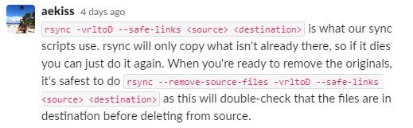

# 95 How to create a 3D numpy array filled with NaNs

- `array = np.full((47, 50, 90), np.nan)`
- this array has dimenstions [47, 50, 90] and filled with `np.nan`
- using `np.zeros()` and `np.empty()` does not really work as I get somehow really big numbers (à la 1e304) instead of just `zeros` or `nan`s

# 96 How to interpolate a gridded 2D or 3D field using `scipy.interpolate2d()`

```
# the interpolation here
for z in range(len(data.st_ocean)): # loop over all depth layers
    # create interpolation function         (old x-axis,    old y-axis,    old data            )
    function = scipy.interpolate.interp2d(data.xt_ocean, data.yt_ocean, data[z,:,:].fillna(1e6)) # fill all nan with 9999

    for i in range(len(x_r)): # loop through all the grid cells and interpolate the data onto the rotated grid
        for j in range(len(y_r)):
            interpolated_data[z,i,j] = function(lon_rot[i,j], lat_rot[i,j])

    # print out statement every 5-th z level to see progress through the loops
    # if z % 20 == 0: print('up to st_ocean level '+ str(z) + ' done')

# to get the nan back, replace all data that is above 2°C with nan
# this is a valid assumption because ENSO-induced temperature anomalies are never bigger than that
interpolated_data[interpolated_data>2]=np.nan
```

# 97 How to include the crown icon at the top of my `LaTeX` manuscript

```
\journalname{Geophysical Research Letters}
\begin{document}
\begin{center}\includegraphics[width=.1\textwidth]{crown}\end{center}vspace{-1cm}
\title{Subsurface warming of West Antarctic coastal waters linked to El Ni\~no events}
```

# 98 How to order a numbered list in word in descending order

- copy the list in ascending order (i.e., 1, 2, 3, …)
- paste your list as ‘Keep Text Only’
- select the newly pasted list, then go to the `HOME` tab, in the `PARAGRAPH` section click `SORT` (the symbol with AZ and downward pointing arrow)
- select `Sort by Descending`

# 99 How to interpolate a 2D field using scipy

```
import scipy
# create interpolation function      (           old x-axis,            old y-axis,     old data)
function = scipy.interpolate.interp2d(ACCESS01_ABS.yt_ocean, ACCESS01_ABS.st_ocean, ACCESS01_ABS)
interp_ACCESS01_ABS = function(SOSE_ABS.YC, SOSE_ABS.Z*-1) # use function to interpolate onto SOSE grid

plt.figure(figsize=(16,3))
plt.subplot(1,3,1); SOSE_ABS.plot(vmin=-4,vmax=4, cmap='RdBu_r'); plt.title('SOSE', fontsize=16)
#                                 ( new x-axis, new y-axis, new data)
plt.subplot(1,3,2); plt.pcolormesh(SOSE_ABS.YC, SOSE_ABS.Z, interpolated_data, vmin=-4,vmax=4, cmap='RdBu_r'); plt.colorbar(); plt.title('ACCESS-OM2 1/10°', fontsize=16)
plt.subplot(1,3,3); plt.pcolormesh(SOSE_ABS.YC, SOSE_ABS.Z, interpolated_data-SOSE_ABS, vmin=-4,vmax=4, cmap='RdBu_r'); plt.colorbar(); plt.title('ACCESS-OM2 1/10° - SOSE', fontsize=16)
```

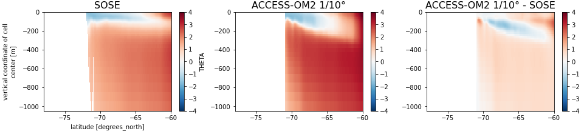

# 100 How to submit a MATLAB job on gadi

`qsub -I -l ncpus=1,mem=15GB,wd -q express -lsoftware=matlab_unsw -lstorage=gdata/e14+gdata/hh5 -X'` - Never tried it and saved if I need to ever use it. Command send to me by Ryan

# 101 How to replace all zeroes in an xarray array with Nans

`d.where(d != 0)` # replaces all zeros with NaN in array `d`

# 102 How to interpolate an xarray array onto another xarray array

```
ds1 = ds1.rename({'yt_ocean': 'y_ocean', 'xt_ocean': 'x_ocean'}) # rename coordinates so that I can multiply later on
ds2_interp = ds2.interp(yu_ocean = ds1.y_ocean.values, xu_ocean = ds1.x_ocean.values).rename({'yu_ocean': 'y_ocean', 'xu_ocean': 'x_ocean'})

ds1 * ds2_interp # this works now
```

# 103 How to get the number from a numpy array

`a = numpy.timedelta64(2623680,'ns')` is what I have, then use `a.astype('int')` to get the value `2623680`

# 104 How to see ‘The most accurate online ruler’

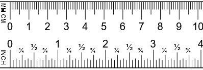

# 105 How to split the Table of Contents in LaTeX over two pages

Within the body text, right before the fifth chapter, you could add a line break to the .toc (in my hmaurice template: chapter.tex) file, for example:

```
\addtocontents{toc}{\protect\newpage}
```

# 106 How to mask data in xarray with multiple conditions

```
sign = uas_anom_EN.where(((uas_anom_EN.lat<-60) & (uas_anom_EN.lat>-75)), 1)
sign.plot()
```

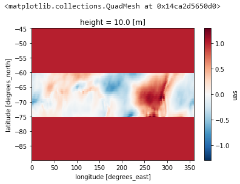

# 107 How to display an automatic ‘Yes’ vs. ‘No’ message in excel

```
=IF(COUNTA(A24:A28)>3,"It's ON!","Need more people")
```

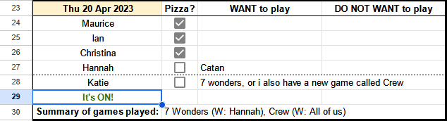

# 108 How to see the list of quarantined files on /scratch

`nci-file-expiry list-quarantined`

# 109 How to place a figure in LaTeX where I want it

- Try `\begin{figure}[!htb]`. In nearly all cases it helps.
- `h` Place figure here, if possible
- `t` Place figure at the top of a page
- `b` Place figure at the bottom of a page and
- `!` Over-ride default LaTeX figure placement (do not use the parameter values).

# 110 How to end the abstract in a paper

m.england:

```
I'll be blunt: I'm not at all a fan of papers that end by just saying their work shows the need for more work!  Isn't that an infinite loop!?!   :-(
Hence my edits here.
May 10, 2023 12:09 AM
```

Do:

```
Our results highlight the role of ENSO variability in influencing the West Antarctic ice shelves, with potential implications for ice sheet melt.
```

# 111 How to save time series as .txt files using a pandas (pd) data frame

```
import pandas as pd
# create pandas dataframe and save it
d = {'1972': N34_1972, '1982': N34_1982, '1997': N34_1997, '2015': N34_2015, 'Mean': EN_mean}; df = pd.DataFrame(data=d)
df.to_csv('/g/data/e14/mv7494/ENSOAnt_data/Fig1d_Time_Series_Composite_EN.nc', sep='\t', index=False) # saving the data frame using csv
plt.plot(df) # to check if all okay
```

This preserves the column headers

# 112 How to create and safe a netcdf file from scratch

```
ds3 = xr.Dataset({'temp_anom_ABS_EN': (('depth', 'distance'), interpolated_temp_EN_ABS),
                 'isopycnals_ABS_EN': (('depth', 'distance'), interpolated_dens_clim_ABS),
                 'isotherms_ABS_EN': (('depth', 'distance'), interpolated_temp_clim_ABS)}, # the masked out isotherms for the subsurface used to plot only the 0°C isotherm
                 attrs=dict(Units='[°C, kg m$^{-3}$, °C]',
                            Author = 'Maurice F. Huguenin',
                            Created = '2023-06-14',
                            Mail = 'm.huguenin-virchaux@unsw.edu.au',
                            Funding = 'UNSW (Program code 1476), ARC ACEAS (ARC Grant No. SR200100008), ARC CLEX (ARC Grant No. CE170100023)'))
ds3['distance'] = y_r; ds3['depth'] = temp_clim.st_ocean.values # fill in the coordinates
ds3.to_netcdf('/g/data/e14/mv7494/ENSOAnt_data/Fig2' + fig[f] + '_Temperature_anoms_' + suffix + '.nc')
```

# 113 How to start Matlab on gadi

```
module load matlab
module load matlab_license/unsw
matlab -nodisplay -nodesktop -nosplash
```

# 114 How to open all .nc files in all subfolders

```
import glob
base_era = '/g/data/rt52/era5/single-levels/monthly-averaged/sst/'
filenames = glob.glob(base_era + '*/*.nc')  # list of all .nc files available in the subfolders
era5_sst = xr.open_mfdataset(filenames).sst[:720,:,:] # open all the files
era5_sst
```

# 115 How to loop through a time series in chunks of let’s say 10 iterations

- selecting 0:9, then 10:19, then 20:29, etc.

```
a = np.linspace(0,27,28) # example of time series
def chunker(seq, size): # function that lets me loop through a time series in chunks of x values
    return (seq[pos:pos + size] for pos in range(0, len(seq), size))
for group in chunker(a, 10): # select chunks of 10
   print(repr(group),)
```

- and this gives me as output:

```
array([0., 1., 2., 3., 4., 5., 6., 7., 8., 9.])
array([10., 11., 12., 13., 14., 15., 16., 17., 18., 19.])
array([20., 21., 22., 23., 24., 25., 26., 27.])
```

# 116 How to do a moving average in a numpy array

```
plt.plot(time, ts, label='NOAA')
def moving_average(x, w): # define moving average function
    return np.convolve(x, np.ones(w), 'same') / w # mode = 'same' to retain original array length
plt.plot(time, moving_average(ts, 12), label='NOAA 12-month running mean')
```

# 117 How to mask out multiple regions of the global ocean simultaneously

- For example, mask out the three IPO regions that are used for the tripole index
- Region 1: 25°N–45°N, 140°E–145°W
- Region 2: 10°S–10°N, 170°E–90°W
- Region 3: 50°S–15°S, 150°E–160°W
- The climatology time period is now Jan 1971 to Jan 2000

```
ds = jra55_ssta[0,:,:]
# select the three IPO regions and mask out data outside the region with zero
ds1 = (ds.where(ds.lat> 25).where(ds.lat< 45).where(ds.lon>140).where(ds.lon<215)).notnull().astype('int')
ds2 = (ds.where(ds.lat>-10).where(ds.lat< 10).where(ds.lon>170).where(ds.lon<270)).notnull().astype('int')
ds3 = (ds.where(ds.lat>-50).where(ds.lat<-15).where(ds.lon>150).where(ds.lon<200)).notnull().astype('int')
IPO_mask = (ds1 + ds2 + ds3) # combine the three region to one mask
IPO_mask = IPO_mask.where(IPO_mask != 0) # replace all zero with nan
(ds*IPO_mask).plot()
```

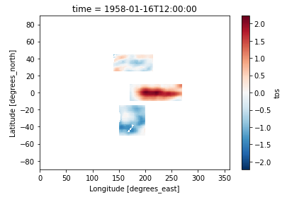